# Multiple factor analysis documentation

## Introduction

This is the documentation file for the package *MFA01*, MFA is short for multiple factor analysis, which is an extension of principle componenet analysis (PCA) to process multiple data sets and their correlations. It generally computed in two steps:

- Step 1: compute PCA of each observation table
- Step 2: aggregate all normalized data tables into a grand table, then compute a non-normalized PCA on it to get the factors scores for analysis.

In addition, partial factor scores and variable loadings are also computed in the process. In this package, visualization tools such as generic functions for print, plot and tabularizing results are also provided. In addition, the package provides auxiliary functions to compute *summaries of eigenvalues*, *contributions*, *$R_V$ coefficients*, *coefficients to study the between table structure* as well as *$L_q$ coefficients* and *Bootstrap* method to estimate the stability of the compromise factor scores. A shiny application is included in the package for interactive visualiztion of the MFA results of the default data set in the folder ‘/data’.

The package functionalities are discussed with R code illustration in the following sections.

## Main function to perform mfa

To install the package, go to the R file ‘install.R’, use ‘setwd()’ to change the working directory to ‘your_path/MFA01’, and run the file.

```r
source("install.R")
```

Then the MFA package should be installed. To create an ‘mfa’ object with default data set, simply run

```r
library(MFA01)
mfa_obj=MFA()
```

Or provide data sets by

```r
mfa_obj=MFA(data='your_data_set')
```

The mfa object computes the eigenvalues of the grand data table, which can be visualized by

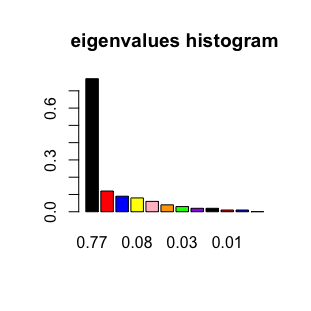

Eigenvalue_hist

```r
plot_eig(mfa_obj)
```

A matrix of the common factor score can be accessed by

```r
mfa_obj$cfs
```

Other elements of the mfa object include:

```r
attributes(mfa_obj)$names
```

[1] “assessors” “index_lists” “weights” “eigen” “cfs” “fl”  
[7] “pfl” “pfs”

To see a summary of what the object returns

```r
mfa_obj
```

Number of tables/blocks for analysis: 10

Weight of tables:

0.240983 0.2386034 0.2748748 0.2728329 0.3065003 0.3023908 0.4167984 0.2724079 0.2635522 0.308608

First two eigenvalues: 0.7702551 0.1229254

First component of common factor scores:

-0.9802057 -0.8088651 -0.7610058 -1.114984 1.372757 1.264015 0.8082827 0.9253423 -0.6689538 0.07316059 -0.4761088 0.3665652

Facor loadings for the first table (1st component):

-0.2943913 -0.2665541 -0.2599726 0.2411168 0.2863237 -0.232907

## Generic methods

### plotting function

The compromise of the tables can be viewed by calling

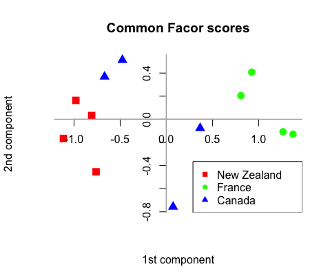

common_factor_score

```r
plot(mfa_obj)
```

One can also specify the options for the ‘plot’ function to view partial factor score and variable loadings by

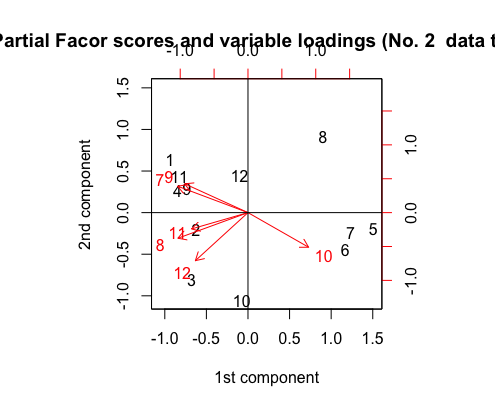

partial_factor_score_loading

```r
plot(mfa_obj,FALSE,pfl=TRUE,pfs=TRUE,num=2)
```

### Related methods: contributions

The summaries of eigenvalues can be obtained by

```r
ev.summary(mfa_obj)
```

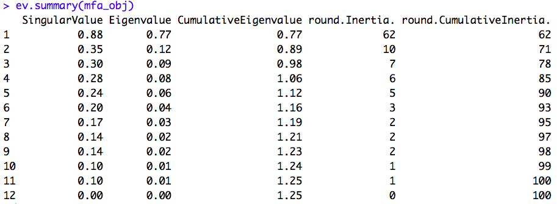

eigenvalue_summary_table

Other derived output from MFA is a series of decriptive statistics called *contributions*. Three types of contributions can be computed

1. contribution of an observation to a dimension
2. contribution of a variable to a dimension
3. contribution of a table to a dimension

These can be computed by calling

```r
ctr.obs(mfa_obj)
ctr.var(mfa_obj)
ctr.table(mfa_obj)
```

Note, the output of the results are suppressed for clarity of the document.

### Coefficients to study the Between-Table structure

The $R_V$ coefficient is used to study the similarity between two tables. It can be obtained by

```r
table1=mfa_obj$assessors[[1]]
table2=mfa_obj$assessors[[2]]
RV(table1,table2)
```

[1] 0.868

The $R_V$ table, $L_g$ coefficient and table can also be computed

```r
data=cbind(mfa_obj$assessors[[1]],mfa_obj$assessors[[2]],mfa_obj$assessors[[3]])
RV_table(data)
Lg(table1,table2)
Lg_table(data)
```

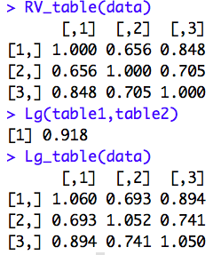

R_V_table_Lg_etc

### Bootstrap

The package also provides ‘bootStrap’ function such that one can use to estimate the stability of the compromise factor score.

```r
bootStrap(mfa_obj)
```

## shiny app

A shiny application is provided for interative visualization of the plots and tables. One can open the file ‘server.R’ or ‘ui.R’, check the path and then run the app to see the results.

The interface of the app looks like

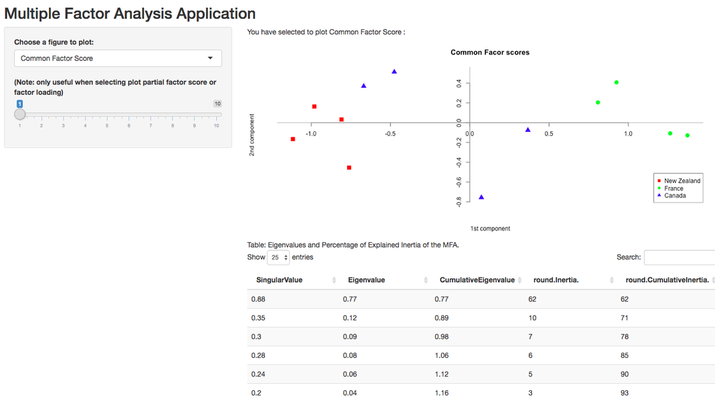

shiny_app_interface

One can use the drop down list to choose which plot to show and slide the number bar to choose which table to plot the partial factor scores and laoding.